# Lection 1 Introduction to Python

**Definition**

> Python is an interpreted, high-level and general-purpose programming language. Python's design philosophy emphasizes code readability with its notable use of significant whitespace. Its language constructs and object-oriented approach aim to help programmers write clear, logical code for small and large-scale projects.

> Python is developed by Guido van Rossum

> First version was delivered in 1991

**Python is pretty popular**

[figure not shown]

**Why people use Python?**

- Software Quality (readability, easy to understand)
- Developer productivity (smaller codebase, without lengthy compile)
- Portability (all major computer platforms)
- Support libraries (standard library + third-party domain)
- Component integration (C, C++, C#, ...)
- Enjoyment

**Where can I use Python?**

- System programming (files, sockets, process, threads, re, command-line arguments, shell-command launchers, CSV, XML, JSON, etc.)
- GUI (Tkinter, Qt, Kivy, etc.)
- Web (Django, Flask, web2py, etc.)
- Component Integration (SWIG for C-like code, Jython for Java, IronPython for C#)
- Database Programming (SQLAlchemy, all modern databases)
- Rapid prototyping
- Numeric and Scientific programming, Data Analysis, ML (NumPy, pandas, SciPy, matplotlib, etc.)
- Testing (pytest + requests)
- And many more...

# **Syntax crash course**

```python
print("Hello world!")
```

```
Hello world!
```

```python
# Assignment
a = 1
b = 2
c, d = 3, 4
a, b, c , d
```

[output not shown]

```python
# Function calls
import math

math.pow(2, 3)
```

```
8.0
```

```python
# if/elif/else
case = 2
if case == 1:
    print("1")
elif case == 2:
    print("2")
else:
    print("Other")
```

```
2
```

```python
# For iteration
for i in range(1, 3):
    print(i, end=" ")
```

```
1 2
```

```python
# Loop
a, b = 1, 3
while b > a:
    print("Hello")
    a += 1
else:
    print("Finish")
```

```
Hello
Hello
Finish
```

```python
# Break, continue
a = 0
while True:
    a += 1
    if a % 2 == 0:
        continue
    if a > 3:
        break
    print(a)
```

```
1
3
```

```python
# Function definition, return, pass placeholder
def myfunc():
    pass

def none_func():
    print("Just printing")

def super_func():
    return 1
```

```python
def factorial(n):
    match n:
        case 0 | 1:
            return 1
        case _:
            return n * factorial(n - 1)
factorial(5)
```

[output not shown]

```python
# import, from
import sys
from sys import version
# from sys import *
import os
import math
import random

print(sys.version)
print(version)
print()
print(os.getcwd())
print(math.pi)
print(random.random())
```

```
3.9.1 (tags/v3.9.1:1e5d33e, Dec  7 2020, 17:08:21) [MSC v.1927 64 bit (AMD64)]
3.9.1 (tags/v3.9.1:1e5d33e, Dec  7 2020, 17:08:21) [MSC v.1927 64 bit (AMD64)]

C:\Users\Andrei_Zhidelev\projects\lectures\Lecture_1_Introduction
3.141592653589793
0.0747772141476386
```

```python
# Class
class A:
    pass

a = A()
print(a)
```

```
<__main__.A object at 0x00000233F5828D60>
```

```python
# Exceptions (try/except/finally, raise)

try:
    raise ValueError("message")
except Exception as e:
    print(e)
finally:
    print("I am a final block!")
```

```
message
I am a final block!
```

```python
# Context manager
with open("text.txt") as f:
    print(f.read())
```

```
I am a file with some text!
```

**Builtin objects**

- Numbers 123,3.14,3+4j,0xef,Decimal,Fraction
- Strings ‘spam’,”Bob’s”,b’ax01c’,u’spxc4m’
- Lists [1,[2,’Three’],4.5], list(range(10))
- Dictionaries {‘food’:’spam’,’taste’:’yum’},dict(hours=10)
- Tuples (1,’spam’,4,’U’),tuple(‘spam’), namedtuple
- Files open(‘eggs.txt’)
- Sets {1,’a’,’bc’}, set(‘abc’)
- Other core types
- Program unit types
- Implementation-related types (compiled code, stack tracebacks)

**Data**

facts representation, terms or instructions in format suitable for processing.

**Data structures**

is a data organization, management, and storage format that enables efficient access and modification

A mutable object can be changed after it's created, and an immutable object can't.

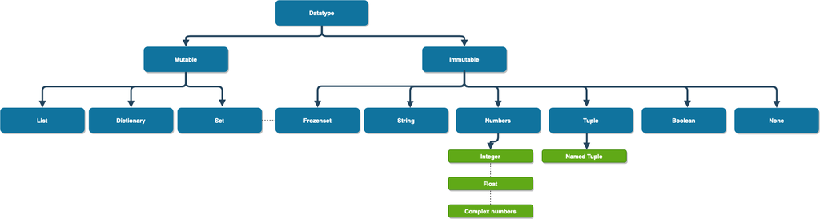

# Strings

Ordered chars sequence, used to store and represent text information.

Starting from Python 3.x strings Unicode chars sequence.

**String literals**

```python
print("python" == 'python')

print("we don't miss Python lectures")
print('we don\'t miss Python lectures')
```

```
True
we don't miss Python lectures
we don't miss Python lectures
```

```python
print('Guido van Rossum: "Python is an experiment in how much freedom programmers need."')
```

```
Guido van Rossum: "Python is an experiment in how much freedom programmers need."
```

```python
# valid, but prone to mistakes
a = "cat " \
    "dog"

# better version, black will format your code (almost) like this
b = ("cat "
    "dog")

print(a)
print(b)
print("cat"" dog")
print("cat"                                      " dog")
```

```
cat dog
cat dog
cat dog
cat dog
```

## Multiline strings

```python
big = """
a very very
much bigger
than normal one
"""

print(big)
```

```
a very very
much bigger
than normal one
```

**Escape Characters**

To insert characters that are illegal in a string, use an escape character.

```python
problem = 'C:\teeeeeeext.txt'
no_problem = r'C:\teeeeeeext.txt'
no_problem_2 = 'C:\\teeeeeeext.txt'

print(problem, no_problem, no_problem_2, sep='\n')
```

```
C:	eeeeeeext.txt
C:\teeeeeeext.txt
C:\teeeeeeext.txt
```

# Character encoding

**ASCII** (American Standard Code for Information Interchange) - a 7-bit character code where every single bit represents a unique character.

**Unicode** - is a specification that aims to list every character used by human languages and give each character its own unique code.

**Byte char representation**

- Unicode Transformation Format (UTF-8, UTF-16, UTF-32) - N bit for each char
- Universal Character Set (UCS-2, UCS-4) - N byte for each char

**Flexible String Representation**

Python 3.3 (PEP-393)

- If string contains only ASCII, each char is represented by 1 byte. (UCS-1)
- If max code of any string char is more than 2^16, use UCS-2.
- In other cases - UCS-4.

https://www.python.org/dev/peps/pep-0393/

```python
var = "Ы"

print(ord(var))
print(chr(ord(var)))
```

```
1067
Ы
```

```python
# the letter, ß, called Eszett (IPA: [ɛsˈtsɛt]) or scharfes S (IPA: [ˈʃaʁfəs ˈʔɛs], lit. "sharp S"),
# represents the /s/ phoneme in Standard German when following long vowels and diphthongs
char = "\N{LATIN SMALL LETTER SHARP S}"
char
```

```
'ß'
```

```python
print('s'.upper())
print('S'.lower())
```

```
S
s
```

```python
print('ß'.lower() == 'SS'.lower())
print('ß'.casefold() == 'SS'.casefold())
print(len('ß'.lower()), len('ß'.casefold()))
```

```
False
True
1 2
```

**ascii(), str(), repr()**

**Common**

Methods to get objects string representation

**What's the difference**

**repr** - “official” string representation of an object

**str** - nicely printable string representation of an object -- humanreadable

**ascii** - like repr, but change non-ASCII symbols to escape characters

```python
import datetime
today = datetime.datetime.now()

print("str() -", str(today),
      "\nrepr() -", repr(today))

mot = "Les garçons"
print("\nrepr() -", repr(mot),
      "\nascii() -", ascii(mot))
datetime.datetime(2019, 11, 7, 18, 33, 17, 341678)
```

```
str() - 2021-03-17 10:35:47.200950
repr() - datetime.datetime(2021, 3, 17, 10, 35, 47, 200950)

repr() - 'Les garçons'
ascii() - 'Les gar\xe7ons'
```

```
datetime.datetime(2019, 11, 7, 18, 33, 17, 341678)
```

**Method - is an function associated with object and giving access to manipulate him**

```python
example = "Python is awesome"
print(example.split('is'))
print(example.split())
```

```
['Python ', ' awesome']
['Python', 'is', 'awesome']
```

**find() - to get substring index**

```python
"Python is awesome".find("aw")
```

```
10
```

**If no match return -1**

```python
"Python is awesome".find("laaaaaaaa")
```

```
-1
```

**Find beginning from right end**

```python
"Python is awesome".rfind("some")
```

```
13
```

**Another options to find substring index**

```python
"Python is awesome".index("Py")
```

```
0
```

```python
"Python is awesome".rindex("o")
```

```
14
```

**But what's the difference between index and find?**

```python
"Python is awesome".index("Snake")
```

```
---------------------------------------------------------------------------
ValueError                                Traceback (most recent call last)
<ipython-input-36-71cd05ae63c6> in <module>
----> 1 "Python is awesome".index("Snake")

ValueError: substring not found
```

**Beginning and end of search**

```python
foo = "some something"
print(foo.find("some", 1))
print(foo.index("some", 1, 9))
```

```
5
5
```

**Count number of occurences in string**

```python
"some something".count("some ")
```

```
1
```

**Membership testing**

```python
"abra" in "abracadabra"
```

```
True
```

```python
print("" in "abracadabra")
print("abracadabra".rfind(""))
print("abracadabra".index(""))
```

```
True
11
0
```

**Strings could be concatenated**

```python
first = "lenin"
second = "grib"
third = first + " " + second + " "
print(third)

# merge using given symbol

" ".join([first, second])
```

```
lenin grib
```

```
'lenin grib'
```

**And duplicated**

```python
print("hello " * 10)
```

```
hello hello hello hello hello hello hello hello hello hello
```

**String slicing**

```python
example = '0123456'

print(example[:2])
print(example[:-1])
print(example[2:3])
print(example[3:-1])
print(example[::2])
```

```
01
012345
2
345
0246
```

**Can we mutate string?**

```python
# Nope. Only create new object
"lenin grib !".replace("grib ", "molodec!")
```

```
'lenin molodec!!'
```

**Trim whitespace chars from the beginning and the end**

S.lstrip([chars]) - from begging

S.rstrip([chars]) - from end

S.strip([chars]) - both

```python
user_input = '   \t My name is \t Vasya \n\n\n'

user_input.strip()
```

```
'My name is \t Vasya'
```

**Change cases**

```python
example = "test"
print()
print(
    "Upper case - " + example.upper(),
    "Title - " + example.title(),
    "Lower case - " + example.lower(),
    "Capitalize - " + example.capitalize(),
    "Swapcase - " + example.swapcase(),
    sep="\n",
)
```

```
Upper case - TEST
Title - Test
Lower case - test
Capitalize - Test
Swapcase - TEST
```

**Strings are immutable**

**Get some information about string**

*S.isdigit()* - consist only from digits

*S.isalpha()* - consist only from letter

*S.isalnum()* - consist both from letters and digits

*S.islower()* - consist from chars in lowercase

*S.isupper()* - consist from chars in uppercase

*S.istitle()* - begins from capitalized char

*S.isspace()* - Check if all the characters in the text are whitespaces:

*S.startswith(pattern)* - begins from pattern

*S.endswith(pattern)* - ends with pattern

```python
s = 'blah blah'
s[2] = "A"
```

```
---------------------------------------------------------------------------
TypeError                                 Traceback (most recent call last)
<ipython-input-55-f4ca9c12eb8d> in <module>
      1 s = 'blah blah'
----> 2 s[2] = "A"

TypeError: 'str' object does not support item assignment
```

**but we can create new objects**

```python
replace_result = s.replace("a", "A")

print(id(replace_result), id(s))
print(s, replace_result)
```

```
2422187534512 2422187532592
blah blah blAh blAh
```

## String formatting

**Approach 1 - real oldschool % (printf-style)**

https://docs.python.org/3/library/stdtypes.html#old-string-formatting

- difficult to read on big strings
- could lead to bugs

```python
price = "cheap"
name = "Linus Torvalds"
"'Talk is %s. Show me the code.' ― %s" % (price, name)
```

```
"'Talk is cheap. Show me the code.' ― Linus Torvalds"
```

**Approach 2 - .format()**

- from Python 2.6
- much readable than %-formatting

```python
price = "cheap"
name = "Linus Torvalds"

"'Talk is {}. Show me the code.' ― {}".format(price, name)
```

```
"'Talk is cheap. Show me the code.' ― Linus Torvalds"
```

```python
price = "cheap"
name = "Linus Torvalds"

"'Talk is {1}. Show me the code.' ― {0}".format(name, price)
```

```
"'Talk is cheap. Show me the code.' ― Linus Torvalds"
```

```python
data = {"price": "cheap", "name": "Linus Torvalds"}
"'Talk is {price}. Show me the code.' ― {name}".format(**data)
```

```
"'Talk is cheap. Show me the code.' ― Linus Torvalds"
```

**Approach 3 - just one simple.. great magnificent f**

- from Python 3.6
- fastest approach (1.4 times faster than .format())
- PEP 498

```python
price = "cheap"
name = "Linus Torvalds"

f"'Talk is {price}. Show me the code.' ― {name}"
```

```
"'Talk is cheap. Show me the code.' ― Linus Torvalds"
```

**Place expression into format brackets**

```python
f"ddddddddddddddddd{2 * 46}"
```

```
'ddddddddddddddddd92'
```

Specify how item should be converted to string:

https://docs.python.org/3/library/string.html#formatexamples

```python
print(f'{0.123456789:.2f}')
data = 'very niiice'
print(f'{data:*^30}')
```

```
0.12
*********very niiice**********
```

And never ever call str() on object passed to format methods

```python
obj_1 = [1, 2, 3, 4,]
obj_2 = 1234567

# bad
print('{} -- {}'.format(str(obj_1), str(obj_2)))

# better
print('{} -- {}'.format(obj_1, obj_2))
```

```
[1, 2, 3, 4] -- 1234567
[1, 2, 3, 4] -- 1234567
```

```python
import logging

logger = logging.getLogger(__name__)

# https://docs.python.org/3/howto/logging.html#optimization
# lazy, string will only be interpolated if the message is actually emitted
logger.info("%s occured while doing %s", "error", "action")

# Use lazy % formatting in logging functions pylint
logger.info("{} occured while doing {}".format("error", "action"))
logger.info("%s occured while doing %s" % ("error", "action"))
a, b = "error", "action"
logger.info(f"{a} occured while doing {b}")
```

```python
import logging
logging.basicConfig(level=logging.INFO)
logger = logging.getLogger('Logger')

class SomeClass:
    def __init__(self, name):
        self._name = name
    def __str__(self) -> str:
        print(f"{self._name}: __str__ called!")
        return self._name

sc1 = SomeClass('sc1')
sc2 = SomeClass('sc2')
sc3 = SomeClass('sc3')
logger.debug(f"{sc1}")
logger.debug("{}".format(sc2))
logger.debug("%s", sc3)
```

```
sc1: __str__ called!
sc2: __str__ called!
```

```python
# Getting help
s = "Some object to check"
print(" ,".join(dir(s)))
print(help(s.replace))
```

```
__add__ ,__class__ ,__contains__ ,__delattr__ ,__dir__ ,__doc__ ,__eq__ ,__format__ ,__ge__ ,__getattribute__ ,__getitem__ ,__getnewargs__ ,__gt__ ,__hash__ ,__init__ ,__init_subclass__ ,__iter__ ,__le__ ,__len__ ,__lt__ ,__mod__ ,__mul__ ,__ne__ ,__new__ ,__reduce__ ,__reduce_ex__ ,__repr__ ,__rmod…
Help on built-in function replace:

replace(old, new, count=-1, /) method of builtins.str instance
    Return a copy with all occurrences of substring old replaced by new.

      count
        Maximum number of occurrences to replace.
        -1 (the default value) means replace all occurrences.

    If the optional argument count is given, only the first count occurrences are
    replaced.

None
```

**Popular IDEs**

- PyCharm https://www.jetbrains.com/pycharm/
- VSCode https://code.visualstudio.com/

**Useful links**

VSCode Python tutorial https://code.visualstudio.com/docs/python/python-tutorial

Python official documentation https://docs.python.org/3/

How to run python scripts https://realpython.com/run-python-scripts/

Book "Python 3 Module of the Week" - stdlib with examples https://pymotw.com/3/

Virtual Environment https://realpython.com/python-virtual-environments-a-primer/

**Homework**

- Install the last version of Python
- Create a repo on a Github
- Copy `https://github.com/Python-TestAutomation-Training-Course/STA-with-Python-1/Lecture_1_Introduction_homework` to your repo
- Commit files
- Create a virtual environment
- Install dependencies from requirements.txt with command `pip install -r requirements.txt`
- Run tests with command `pytest` (1 should pass and 5 fail)
- Create a new branch
- Implement `get_length` and `remove_spaces` functions to fix tests
- Push your changes and make a Pull Request for your repo
- Assign PR to https://github.com/ZoiaOchikova